# Lab 6b - Statistical Network Models

Douglas Luke

Julyl 16, 2021

## Introduction

This lab corresponds to Chapter 11 - Statistical Network Models.

The statistical models covered in this chapter and lab are ERGMs: exponential random graph models. In R these models are available in the `ergm` package which is included as part of `statnet`. Note that you should install the `latticeExtra` package if you want to create the MCMC diagnostics plots for the ERGM models.

```r
library(statnet)
library(UserNetR)
library(latticeExtra)
```

## Background

Review the material presented at the beginning of Chapter 11, particularly the description of the basic ERGM model and the variety of terms that can be included in the model.

The examples in this chapter make use of network data contained in the `TCnetworks` data object. Unlike most of the other datasets contained in `UserNetR`, this object is not an `igraph` or `statnet` network object. Instead, it is a list that contains four different network objects.

The following code loads the list object, extracts the list members into the four network objects.

```r
data(TCnetworks)
class(TCnetworks)
```

```
## [1] "list"
```

```r
TCcnt <- TCnetworks$TCcnt
TCcoll <- TCnetworks$TCcoll
TCdiss <- TCnetworks$TCdiss
TCdist <- TCnetworks$TCdist
summary(TCdiss,print.adj=FALSE)
```

```
## Network attributes:
##   vertices = 25
##   directed = FALSE
##   hyper = FALSE
##   loops = FALSE
##   multiple = FALSE
##   bipartite = FALSE
##   title = IN_Diffusion
##  total edges = 103
##    missing edges = 0
##    non-missing edges = 103
##  density = 0.3433333
##
## Vertex attributes:
##
##  agency_cat:
##    numeric valued attribute
##    attribute summary:
##    Min. 1st Qu.  Median    Mean 3rd Qu.    Max.
##    1.00    2.00    2.00    3.24    5.00    6.00
##
##  agency_lvl:
##    numeric valued attribute
##    attribute summary:
##    Min. 1st Qu.  Median    Mean 3rd Qu.    Max.
##    1.00    1.00    2.00    2.04    3.00    3.00
##
##  lead_agency:
##    numeric valued attribute
##    attribute summary:
##    Min. 1st Qu.  Median    Mean 3rd Qu.    Max.
##    0.00    0.00    0.00    0.04    0.00    1.00
##
##  tob_yrs:
##    numeric valued attribute
##    attribute summary:
##    Min. 1st Qu.  Median    Mean 3rd Qu.    Max.
##    1.00    3.00    4.50    6.76    9.00   21.00
##   vertex.names:
##    character valued attribute
##    25 valid vertex names
##
## No edge attributes
```

```r
summary(TCcnt,print.adj=FALSE)
```

```
## Network attributes:
##   vertices = 25
##   directed = FALSE
##   hyper = FALSE
##   loops = FALSE
##   multiple = FALSE
##   bipartite = FALSE
##   title = IN_Contact
##  total edges = 175
##    missing edges = 0
##    non-missing edges = 175
##  density = 0.5833333
##
## Vertex attributes:
##
##  agency_cat:
##    numeric valued attribute
##    attribute summary:
##    Min. 1st Qu.  Median    Mean 3rd Qu.    Max.
##    1.00    2.00    2.00    3.24    5.00    6.00
##
##  agency_lvl:
##    numeric valued attribute
##    attribute summary:
##    Min. 1st Qu.  Median    Mean 3rd Qu.    Max.
##    1.00    1.00    2.00    2.04    3.00    3.00
##
##  lead_agency:
##    numeric valued attribute
##    attribute summary:
##    Min. 1st Qu.  Median    Mean 3rd Qu.    Max.
##    0.00    0.00    0.00    0.04    0.00    1.00
##
##  tob_yrs:
##    numeric valued attribute
##    attribute summary:
##    Min. 1st Qu.  Median    Mean 3rd Qu.    Max.
##    1.00    3.00    4.50    6.76    9.00   21.00
##   vertex.names:
##    character valued attribute
##    25 valid vertex names
##
## Edge attributes:
##
##  contact:
##    numeric valued attribute
##    attribute summary:
##    Min. 1st Qu.  Median    Mean 3rd Qu.    Max.
##   2.000   2.000   3.000   2.703   3.000   5.000
```

As the book and data help file reveal, these network data come from an evaluation of the Indiana tobacco control program. The first three network objects contain organizational contact, collaboration, and dissemination tie information. The last network object (TCdist), is a little different, and is used to contain the geographic distances between all 25 of the program members.

E: Using basic R and `statnet` tools, how can you tell that `TCdist` is different from the other networks?

```r
components(TCdiss)
```

```
## [1] 1
```

```r
gden(TCdiss)
```

```
## [1] 0.3433333
```

```r
centralization(TCdiss,betweenness,mode='graph')
```

```
## [1] 0.3810419
```

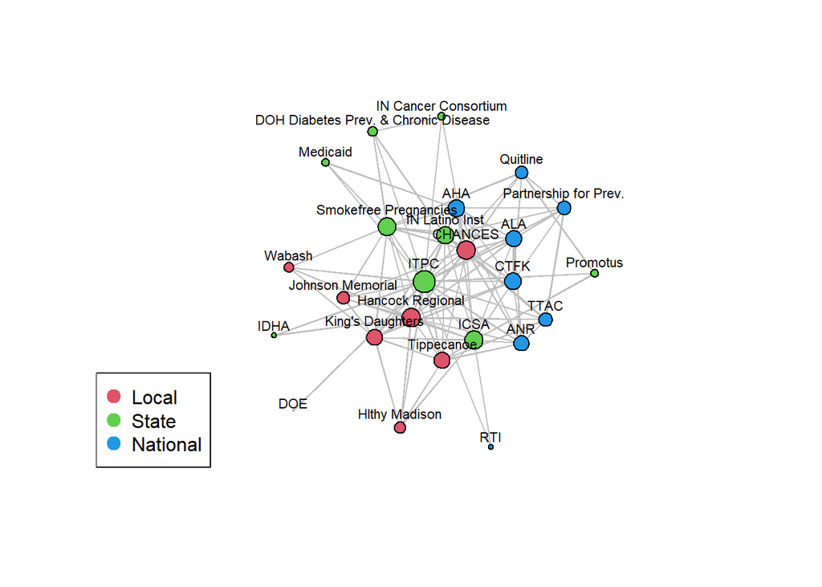

```r
deg <- degree(TCdiss,gmode='graph')
lvl <- TCdiss %v% 'agency_lvl'
plot(TCdiss,usearrows=FALSE,displaylabels=TRUE,
      vertex.cex=log(deg),
      vertex.col=lvl+1,
      label.pos=3,label.cex=.7,
      edge.lwd=0.5,edge.col="grey75")
legend("bottomleft",legend=c("Local","State",
                             "National"),
       col=2:4,pch=19,pt.cex=1.5)
```

## Building ERGM models

As in any type of statistical modeling, it is often useful to start with a baseline, null model. For `ergm` models, this means no covariates, but the model is conditioned on the observed number of ties.

```r
library(ergm)
DSmod0 <- ergm(TCdiss ~ edges,
               control=control.ergm(seed=40))
```

```
## Starting maximum pseudolikelihood estimation (MPLE):
```

```
## Evaluating the predictor and response matrix.
```

```
## Maximizing the pseudolikelihood.
```

```
## Finished MPLE.
```

```
## Stopping at the initial estimate.
```

```
## Evaluating log-likelihood at the estimate.
```

```r
class(DSmod0)
```

```
## [1] "ergm"
```

```r
summary(DSmod0)
```

```
## Call:
## ergm(formula = TCdiss ~ edges, control = control.ergm(seed = 40))
##
## Maximum Likelihood Results:
##
##       Estimate Std. Error MCMC % z value Pr(>|z|)
## edges  -0.6485     0.1216      0  -5.333   <1e-04 ***
## ---
## Signif. codes:  0 '***' 0.001 '**' 0.01 '*' 0.05 '.' 0.1 ' ' 1
##
##      Null Deviance: 415.9  on 300  degrees of freedom
##  Residual Deviance: 385.9  on 299  degrees of freedom
##
## AIC: 387.9  BIC: 391.6  (Smaller is better. MC Std. Err. = 0)
```

The model is estimating the log-odds of observing a tie. So, we can take the logistic transform of the edges estimated parameter to be able to interpret its meaning. In this case it means the overall probability of observing a tie in the network, which is equivalent to its density.

```r
plogis(coef(DSmod0))
```

```
##     edges
## 0.3433333
```

```r
gden(TCdiss)
```

```
## [1] 0.3433333
```

E: Build null ergm models for the contact and collaboration ties as well. Do they have the same parameter estimates as for the dissemination ties? Does that make sense to you?

### Node-attribute terms

More informative ERGM models are built up by including other covariates of interest. Types of covariates in `ergm` are called ‘terms.’ Terms can be node characteristics, node interactions, relational characteristics, and higher order network effects (e.g., degree distributions, triangles, etc.) See the Harris book and Morris (Morris 2008) for more details. Also, to see the internal help for ergm terms, type `?ergm.terms`.

The following plot suggests that agencies with more experience in tobacco control may be more likely to be involved in dissemination ties with other agencies.

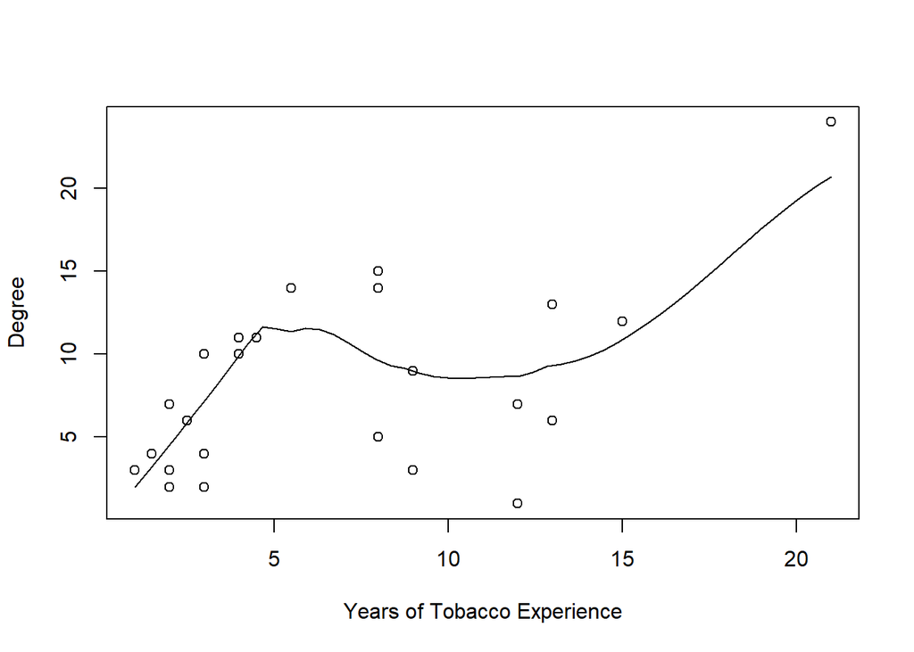

```r
scatter.smooth(TCdiss %v% 'tob_yrs',
               degree(TCdiss,gmode='graph'),
               xlab='Years of Tobacco Experience',
               ylab='Degree')
```

The following model examines the effects of agency experience, and whether the agency is the lead agency, on the likelihood of observing a dissemination tie. This model uses the nodefactor term (for a binary node covariate) and the nodecov term (for a quantitative node covariate).

```r
DSmod1 <- ergm(TCdiss ~ edges +
              nodefactor('lead_agency') +
              nodecov('tob_yrs'))
```

```
## Starting maximum pseudolikelihood estimation (MPLE):
```

```
## Evaluating the predictor and response matrix.
```

```
## Maximizing the pseudolikelihood.
```

```
## Finished MPLE.
```

```
## Stopping at the initial estimate.
```

```
## Evaluating log-likelihood at the estimate.
```

```r
summary(DSmod1)
```

```
## Call:
## ergm(formula = TCdiss ~ edges + nodefactor("lead_agency") + nodecov("tob_yrs"))
##
## Maximum Likelihood Results:
##
##                           Estimate Std. Error MCMC % z value Pr(>|z|)
## edges                     -1.67835    0.32931      0  -5.097  < 1e-04 ***
## nodefactor.lead_agency.1  17.93665  933.55514      0   0.019  0.98467
## nodecov.tob_yrs            0.05994    0.02283      0   2.625  0.00867 **
## ---
## Signif. codes:  0 '***' 0.001 '**' 0.01 '*' 0.05 '.' 0.1 ' ' 1
##
##      Null Deviance: 415.9  on 300  degrees of freedom
##  Residual Deviance: 323.5  on 297  degrees of freedom
##
## AIC: 329.5  BIC: 340.6  (Smaller is better. MC Std. Err. = 0)
```

The coefficients of the fitted model can be extracted from the model object. These can be used to calculate the estimated probability of observing ties for particulary network (dyad) configurations.

So, for example, the above output suggests that agencies with more years of experience in tobacco control will have increased likelihood of being involved in a dissemination tie.

The following code determines the probability of observing a tie between two non-lead agencies, each with 5 years of TC experience.

```r
coef(DSmod1)
```

```
##                    edges nodefactor.lead_agency.1          nodecov.tob_yrs
##              -1.67834874              17.93664921               0.05993665
```

```r
p_edg <- coef(DSmod1)[1]
p_yrs <- coef(DSmod1)[3]
plogis(p_edg + 5*p_yrs + 5*p_yrs)
```

```
##     edges
## 0.2536987
```

Q: If you take the logistic transform of just the edges parameter in this model, what number do you get, and how do you interpret it?

### Dyadic terms

One of the powerful features of statistical network models is to explore dyadic effects. That is, how do characteristics of pairs of actors influence the likelihood that those pairs are connected by a tie? This allows us to explore and test hypotheses about dyadic similarity (homophily) and dissimilarity (heterophily).

Before building a model with dyadic terms, it is usually helpful to explore the raw observed tie patterns with respect to some node categorical attribute. (See the help file for classifiction codes: ?TCnetworks.)

```r
mixingmatrix(TCdiss,'agency_lvl')
```

```
##    1  2  3
## 1 13 24 14
## 2 24 16 23
## 3 14 23 13
```

```
## Note:  Marginal totals can be misleading for undirected mixing matrices.
```

```r
mixingmatrix(TCdiss,'agency_cat')
```

```
##    1  2  3  4  5  6
## 1  0 12  3  2  3  4
## 2 12 19 18  6  1 14
## 3  3 18  0  4  3  2
## 4  2  6  4  1  1  6
## 5  3  1  3  1  0  0
## 6  4 14  2  6  0  4
```

```
## Note:  Marginal totals can be misleading for undirected mixing matrices.
```

Here are three different ways to examine the homophily effects of agency level on dissemination.

```r
DSmod2a <- ergm(TCdiss ~ edges +
              nodecov('tob_yrs') +
              nodematch('agency_lvl'),
              control=control.ergm(seed=40))
```

```
## Starting maximum pseudolikelihood estimation (MPLE):
```

```
## Evaluating the predictor and response matrix.
```

```
## Maximizing the pseudolikelihood.
```

```
## Finished MPLE.
```

```
## Stopping at the initial estimate.
```

```
## Evaluating log-likelihood at the estimate.
```

```r
summary(DSmod2a)
```

```
## Call:
## ergm(formula = TCdiss ~ edges + nodecov("tob_yrs") + nodematch("agency_lvl"),
##     control = control.ergm(seed = 40))
##
## Maximum Likelihood Results:
##
##                      Estimate Std. Error MCMC % z value Pr(>|z|)
## edges                -2.48077    0.34131      0  -7.268   <1e-04 ***
## nodecov.tob_yrs       0.11331    0.02006      0   5.648   <1e-04 ***
## nodematch.agency_lvl  0.68751    0.27698      0   2.482   0.0131 *
## ---
## Signif. codes:  0 '***' 0.001 '**' 0.01 '*' 0.05 '.' 0.1 ' ' 1
##
##      Null Deviance: 415.9  on 300  degrees of freedom
##  Residual Deviance: 342.2  on 297  degrees of freedom
##
## AIC: 348.2  BIC: 359.4  (Smaller is better. MC Std. Err. = 0)
```

```r
DSmod2b <- ergm(TCdiss ~ edges +
              nodecov('tob_yrs') +
              nodematch('agency_lvl',diff=TRUE),
              control=control.ergm(seed=40))
```

```
## Starting maximum pseudolikelihood estimation (MPLE):
```

```
## Evaluating the predictor and response matrix.
```

```
## Maximizing the pseudolikelihood.
```

```
## Finished MPLE.
```

```
## Stopping at the initial estimate.
```

```
## Evaluating log-likelihood at the estimate.
```

```r
summary(DSmod2b)
```

```
## Call:
## ergm(formula = TCdiss ~ edges + nodecov("tob_yrs") + nodematch("agency_lvl",
##     diff = TRUE), control = control.ergm(seed = 40))
##
## Maximum Likelihood Results:
##
##                        Estimate Std. Error MCMC % z value Pr(>|z|)
## edges                  -2.77924    0.36851      0  -7.542  < 1e-04 ***
## nodecov.tob_yrs         0.13314    0.02174      0   6.123  < 1e-04 ***
## nodematch.agency_lvl.1  1.61450    0.49835      0   3.240  0.00120 **
## nodematch.agency_lvl.2 -0.21484    0.39735      0  -0.541  0.58873
## nodematch.agency_lvl.3  1.30157    0.44220      0   2.943  0.00325 **
## ---
## Signif. codes:  0 '***' 0.001 '**' 0.01 '*' 0.05 '.' 0.1 ' ' 1
##
##      Null Deviance: 415.9  on 300  degrees of freedom
##  Residual Deviance: 329.9  on 295  degrees of freedom
##
## AIC: 339.9  BIC: 358.4  (Smaller is better. MC Std. Err. = 0)
```

```r
DSmod2c <- ergm(TCdiss ~ edges +
              nodecov('tob_yrs') +
              nodemix('agency_lvl',base=1),
              control=control.ergm(seed=40))
```

```
## In term 'nodemix' in package 'ergm': Argument 'base' has been superseded by 'levels2', and it is recommended to use the latter.  Note that its interpretation may be different.
```

```
## Starting maximum pseudolikelihood estimation (MPLE):
```

```
## Evaluating the predictor and response matrix.
```

```
## Maximizing the pseudolikelihood.
```

```
## Finished MPLE.
```

```
## Stopping at the initial estimate.
```

```
## Evaluating log-likelihood at the estimate.
```

```r
summary(DSmod2c)
```

```
## Call:
## ergm(formula = TCdiss ~ edges + nodecov("tob_yrs") + nodemix("agency_lvl",
##     base = 1), control = control.ergm(seed = 40))
##
## Maximum Likelihood Results:
##
##                    Estimate Std. Error MCMC % z value Pr(>|z|)
## edges              -1.17567    0.53718      0  -2.189  0.02862 *
## nodecov.tob_yrs     0.13405    0.02225      0   6.026  < 1e-04 ***
## mix.agency_lvl.1.2 -1.58049    0.55005      0  -2.873  0.00406 **
## mix.agency_lvl.2.2 -1.83543    0.60280      0  -3.045  0.00233 **
## mix.agency_lvl.1.3 -1.53626    0.56587      0  -2.715  0.00663 **
## mix.agency_lvl.2.3 -1.70730    0.54454      0  -3.135  0.00172 **
## mix.agency_lvl.3.3 -0.31105    0.61186      0  -0.508  0.61119
## ---
## Signif. codes:  0 '***' 0.001 '**' 0.01 '*' 0.05 '.' 0.1 ' ' 1
##
##      Null Deviance: 415.9  on 300  degrees of freedom
##  Residual Deviance: 329.7  on 293  degrees of freedom
##
## AIC: 343.7  BIC: 369.6  (Smaller is better. MC Std. Err. = 0)
```

Q: Of the three estimated models, which do you prefer? How does AIC help you in model selection?

Q: Using the differential homophily model, what is the probability of two agencies having a dissemination tie, when both agencies have five years of tobacco experience, and both are local agencies?

### Relational predictors

Although not clearly described in the papers and documentation for `ergm`, these models can use other network ties as a relational predictor (covariate). So, for example, you could build a model that test the hypothese that friends in a high school class (friendship tie) are more likely to lend money to each other (money flow tie), compared to non-friends.

Here, we build a model that looks at whether contact ties and the distance between agencies are significantly related to the probability of observing a dissemination tie. The term we use is ‘edgecov’.

```r
as.sociomatrix(TCdist,attrname = 'distance')[1:5,1:5]
```

```
##          1        2        3        4        5
## 1    0.000    1.935  491.868 1869.877    1.275
## 2    1.935    0.000  491.968 1868.980    1.914
## 3  491.868  491.968    0.000 2324.930  493.085
## 4 1869.877 1868.980 2324.930    0.000 1868.612
## 5    1.275    1.914  493.085 1868.612    0.000
```

```r
as.sociomatrix(TCcnt,attrname = 'contact')[1:5,1:5]
```

```
##          ITPC Promotus RTI Quitline IDHA
## ITPC        0        5   4        4    3
## Promotus    5        0   3        4    0
## RTI         4        3   0        2    0
## Quitline    4        4   2        0    0
## IDHA        3        0   0        0    0
```

```r
DSmod3 <- ergm(TCdiss ~ edges +
              nodecov('tob_yrs') +
              nodematch('agency_lvl',diff=TRUE) +
              edgecov(TCdist,attr='distance') +
              edgecov(TCcnt,attr='contact'),
              control=control.ergm(seed=40))
```

```
## Starting maximum pseudolikelihood estimation (MPLE):
```

```
## Evaluating the predictor and response matrix.
```

```
## Maximizing the pseudolikelihood.
```

```
## Finished MPLE.
```

```
## Stopping at the initial estimate.
```

```
## Evaluating log-likelihood at the estimate.
```

```r
summary(DSmod3)
```

```
## Call:
## ergm(formula = TCdiss ~ edges + nodecov("tob_yrs") + nodematch("agency_lvl",
##     diff = TRUE) + edgecov(TCdist, attr = "distance") + edgecov(TCcnt,
##     attr = "contact"), control = control.ergm(seed = 40))
##
## Maximum Likelihood Results:
##
##                          Estimate Std. Error MCMC % z value Pr(>|z|)
## edges                  -4.8506191  0.6296655      0  -7.703  < 1e-04 ***
## nodecov.tob_yrs         0.1287501  0.0282702      0   4.554  < 1e-04 ***
## nodematch.agency_lvl.1  1.7951025  0.6256978      0   2.869  0.00412 **
## nodematch.agency_lvl.2 -0.6460148  0.5081639      0  -1.271  0.20363
## nodematch.agency_lvl.3  1.7218505  0.5468704      0   3.149  0.00164 **
## edgecov.distance       -0.0001840  0.0002533      0  -0.726  0.46776
## edgecov.contact         1.1242535  0.1469568      0   7.650  < 1e-04 ***
## ---
## Signif. codes:  0 '***' 0.001 '**' 0.01 '*' 0.05 '.' 0.1 ' ' 1
##
##      Null Deviance: 415.9  on 300  degrees of freedom
##  Residual Deviance: 237.0  on 293  degrees of freedom
##
## AIC: 251  BIC: 276.9  (Smaller is better. MC Std. Err. = 0)
```

### Local structural terms (dyad dependency)

Local structural predictors can be important elements of a network statistical model, for both substantive reasons, and to improve model stability. (See Harris book and assigned readings for more details.)

These types of models are more complicated: they require different estimation techniques (Markov Chain Monte Carlo, MCMC, for example), they can be less stable, and even with modern computers these models can take a long time to estimate.

```r
DSmod4 <- ergm(TCdiss ~ edges +
              nodecov('tob_yrs') +
              nodematch('agency_lvl',diff=TRUE) +
              edgecov(TCdist,attr='distance') +
              edgecov(TCcnt,attr="contact") +
              gwesp(0.7, fixed=TRUE),
              control=control.ergm(seed=40))
```

```
## Starting maximum pseudolikelihood estimation (MPLE):
```

```
## Evaluating the predictor and response matrix.
```

```
## Maximizing the pseudolikelihood.
```

```
## Finished MPLE.
```

```
## Starting Monte Carlo maximum likelihood estimation (MCMLE):
```

```
## Iteration 1 of at most 60:
```

```
## Optimizing with step length 1.0000.
```

```
## The log-likelihood improved by 0.4284.
```

[output not shown]

```r
summary(DSmod4)
```

```
## Call:
## ergm(formula = TCdiss ~ edges + nodecov("tob_yrs") + nodematch("agency_lvl",
##     diff = TRUE) + edgecov(TCdist, attr = "distance") + edgecov(TCcnt,
##     attr = "contact") + gwesp(0.7, fixed = TRUE), control = control.ergm(seed = 40))
##
## Monte Carlo Maximum Likelihood Results:
##
##                          Estimate Std. Error MCMC % z value Pr(>|z|)
## edges                  -6.3963114  0.9290177      0  -6.885  < 1e-04 ***
## nodecov.tob_yrs         0.1002707  0.0286041      0   3.505 0.000456 ***
## nodematch.agency_lvl.1  1.5675320  0.5875460      0   2.668 0.007632 **
## nodematch.agency_lvl.2 -0.2518558  0.4911344      0  -0.513 0.608088
## nodematch.agency_lvl.3  1.5749889  0.5275917      0   2.985 0.002834 **
## edgecov.distance       -0.0001647  0.0002356      0  -0.699 0.484564
## edgecov.contact         1.0523316  0.1530924      0   6.874  < 1e-04 ***
## gwesp.fixed.0.7         0.8747288  0.3588293      0   2.438 0.014780 *
## ---
## Signif. codes:  0 '***' 0.001 '**' 0.01 '*' 0.05 '.' 0.1 ' ' 1
##
##      Null Deviance: 415.9  on 300  degrees of freedom
##  Residual Deviance: 230.8  on 292  degrees of freedom
##
## AIC: 246.8  BIC: 276.4  (Smaller is better. MC Std. Err. = 0.2045)
```

## Examining fitted ERGM models

### Examine predicted model profiles

Want to look at estimated probabilities for different model configurations (i.e., covariate patterns) to make sure you understand the effects and how they are interrelated. See my book for what these probabilities refer to.

```r
prd_prob1 <- plogis(-6.34 + 2*1*.098 + 1.51 +
                      4*1.042 + .858*(.50^4))
prd_prob1
```

```
## [1] 0.3983428
```

```r
prd_prob2 <- plogis(-6.34 + 2*5*.098 +
                      1*1.04 + .858*(.50^4))
prd_prob2
```

```
## [1] 0.01383837
```

### Transform raw parameter estimates into odds-ratios

Because an ERGM model is a type of logistic model (probability of an observed tie), the raw parameter estimates are appropriately interpreted as log-odds. These can be transformed into odds-ratios by exponentiating the parameters. See Harris, pp. 50-52 for more details.

This code shows how to extract the appropriate coefficient (and standard error) from the model object, and then use it to calculate the odds ratio and confidence interval for the `tob_yrs` parameter. Note that sometimes this is easier to do by hand, rather than remembering the code for extraction.

```r
coef(DSmod4)
```

```
##                  edges        nodecov.tob_yrs nodematch.agency_lvl.1
##          -6.3963113685           0.1002706659           1.5675319627
## nodematch.agency_lvl.2 nodematch.agency_lvl.3       edgecov.distance
##          -0.2518557796           1.5749888806          -0.0001647046
##        edgecov.contact        gwesp.fixed.0.7
##           1.0523316097           0.8747287608
```

```r
CF_tobyrs <- coef(DSmod4)[[2]]
CF_tobyrs
```

```
## [1] 0.1002707
```

```r
summary(DSmod4)$asyse
```

```
##                  edges        nodecov.tob_yrs nodematch.agency_lvl.1
##           0.9290176823           0.0286040945           0.5875460409
## nodematch.agency_lvl.2 nodematch.agency_lvl.3       edgecov.distance
##           0.4911343755           0.5275917281           0.0002356352
##        edgecov.contact        gwesp.fixed.0.7
##           0.1530924406           0.3588293385
```

```r
SE_tobyrs <- summary(DSmod4)$asyse[[2]]
SE_tobyrs
```

```
## [1] 0.02860409
```

Now that we have the appropriate values, the calculations for the OR and CI are straightforward.

```r
OR_tobyrs <- exp(CF_tobyrs)
OR_tobyrs
```

```
## [1] 1.10547
```

```r
LCI <- exp(CF_tobyrs - 1.96*SE_tobyrs)
UCI <- exp(CF_tobyrs + 1.96*SE_tobyrs)
LCI
```

```
## [1] 1.045198
```

```r
UCI
```

```
## [1] 1.169217
```

E: Interpret the odds-ratio and its confidence interval. Calculate the OR and CI for the first agency level homophily term. How do you interpret those values?

Q: The double bracket notation can be somewhat confusing for extracting components of lists in R. What happens when you use only a single set of brackets?

### Examine model fit

It is always important to assess the convergence and fit of the model. Convergence problems will be indicated by error or warning messages, or models that produce networks that do not look like the observed network (density of 1 or 0, for example). Model fit tells us more about how the modeled network is similar to the observed network.

To examine model fit, `ergm` allows us to create a model fit object.

```r
DSmod.fit <- gof(DSmod4,
                 GOF = ~distance + espartners +
                   degree + triadcensus,
                 burnin=1e+5, interval = 1e+5)
summary(DSmod.fit)
```

```
##                     Length Class   Mode
## network.size           1   -none-  numeric
## GOF                    2   formula call
## pval.model            40   -none-  numeric
## summary.model         40   -none-  numeric
## pobs.model             8   -none-  numeric
## psim.model           800   -none-  numeric
## bds.model             16   -none-  numeric
## obs.model              8   -none-  numeric
## sim.model            800   -none-  numeric
## pval.dist            125   -none-  numeric
## summary.dist         125   -none-  numeric
## pobs.dist             25   -none-  numeric
## psim.dist           2500   -none-  numeric
## bds.dist              50   -none-  numeric
## obs.dist              25   -none-  numeric
## sim.dist            2500   -none-  numeric
## pval.deg             125   -none-  numeric
## summary.deg          125   -none-  numeric
## pobs.deg              25   -none-  numeric
## psim.deg            2500   -none-  numeric
## bds.deg               50   -none-  numeric
## obs.deg               25   -none-  numeric
## sim.deg             2500   -none-  numeric
## pval.espart          120   -none-  numeric
## summary.espart       120   -none-  numeric
## pobs.espart           24   -none-  numeric
## psim.espart         2400   -none-  numeric
## bds.espart            48   -none-  numeric
## obs.espart            24   -none-  numeric
## sim.espart          2400   -none-  numeric
## pval.triadcensus      20   -none-  numeric
## summary.triadcensus   20   -none-  numeric
## pobs.triadcensus       4   -none-  numeric
## psim.triadcensus     400   -none-  numeric
## bds.triadcensus        8   -none-  numeric
## obs.triadcensus        4   -none-  numeric
## sim.triadcensus      400   -none-  numeric
```

In addition to looking at the summary, very useful gof plots can be produced:

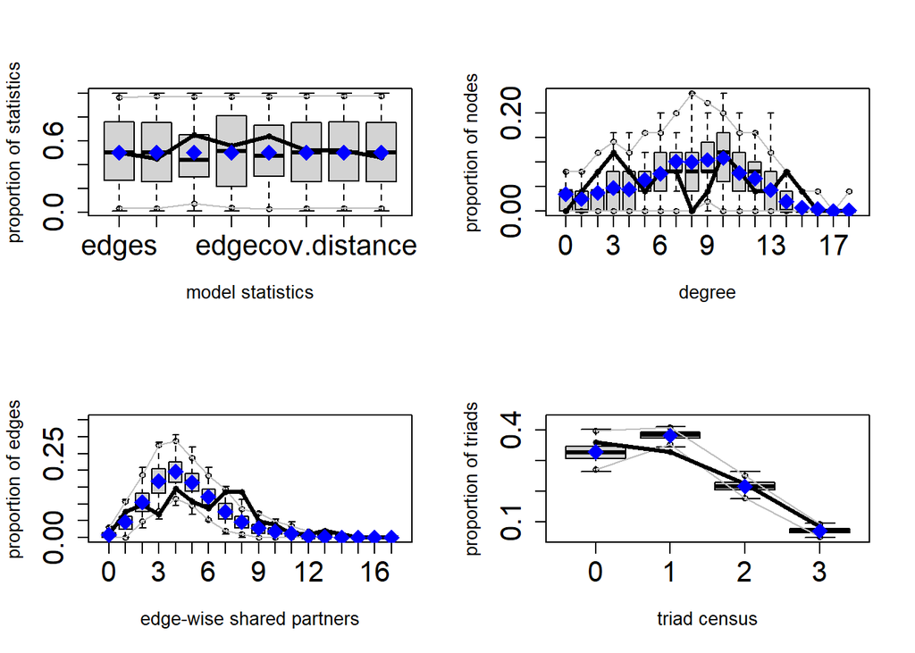

```r
op <- par(mfrow=c(2,2))
plot(DSmod.fit,cex.axis=1.6,cex.label=1.6)
```

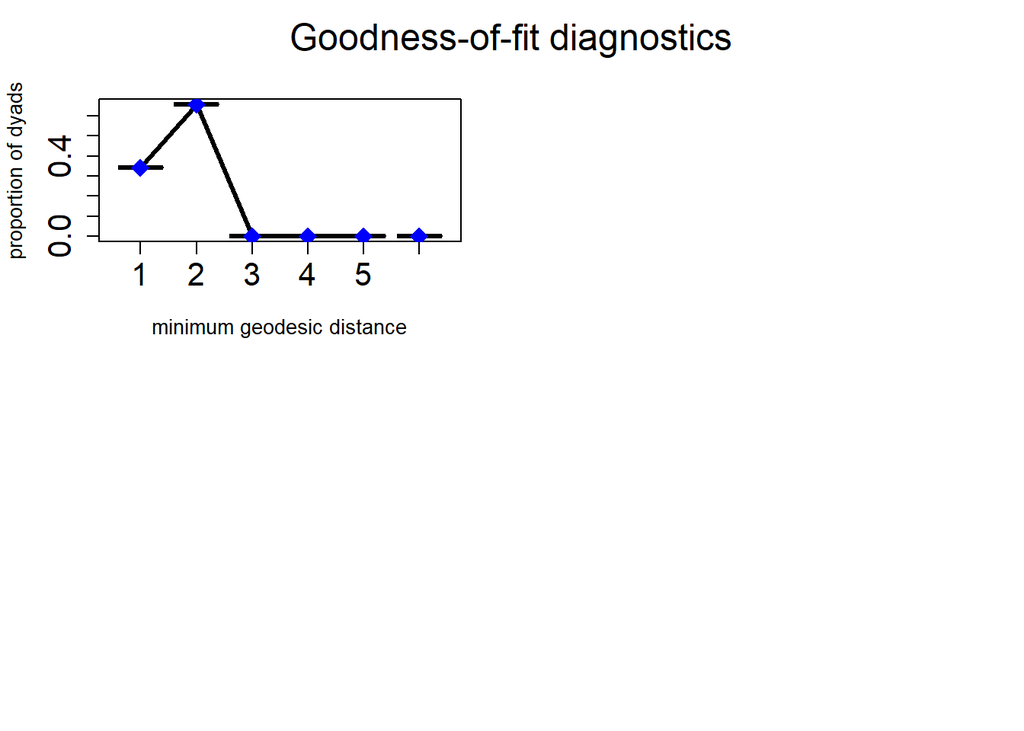

```r
par(op)
```

More sophisticated model diagnostics can also be produced, allowing you to look ‘under the hood’ at the estimation process. This can be useful to diagnose model problems.

```r
mcmc.diagnostics(DSmod4)
```

```
## Sample statistics summary:
##
## Iterations = 13824:343040
## Thinning interval = 512
## Number of chains = 1
## Sample size per chain = 644
##
## 1. Empirical mean and standard deviation for each variable,
##    plus standard error of the mean:
##
##                             Mean       SD  Naive SE Time-series SE
## edges                    0.06211    6.201   0.24434        0.32514
## nodecov.tob_yrs         -2.82065   99.620   3.92559        5.37090
## nodematch.agency_lvl.1   0.17702    1.817   0.07158        0.09434
## nodematch.agency_lvl.2  -0.58385    2.641   0.10407        0.13975
## nodematch.agency_lvl.3  -0.20342    2.289   0.09019        0.11671
## edgecov.distance       115.08581 5462.500 215.25267      272.26445
## edgecov.contact         -1.46118   15.645   0.61649        0.89682
## gwesp.fixed.0.7          0.10242   14.298   0.56341        0.69974
##
## 2. Quantiles for each variable:
##
##                             2.5%       25%     50%      75%     97.5%
## edges                     -12.93    -4.000  0.0000    4.000    12.000
## nodecov.tob_yrs          -207.46   -63.125 -2.7500   65.625   189.050
## nodematch.agency_lvl.1     -3.00    -1.000  0.0000    1.000     3.925
## nodematch.agency_lvl.2     -6.00    -2.000 -1.0000    1.000     4.000
## nodematch.agency_lvl.3     -5.00    -2.000  0.0000    1.000     4.000
## edgecov.distance       -11100.81 -3463.016 11.2360 3935.960 10728.398
## edgecov.contact           -33.00   -13.000 -1.0000    9.000    27.000
## gwesp.fixed.0.7           -28.87    -9.598  0.8339    9.884    27.837
##
##
## Are sample statistics significantly different from observed?
##                edges nodecov.tob_yrs nodematch.agency_lvl.1
## diff.      0.0621118      -2.8206522             0.17701863
## test stat. 0.1910322      -0.5251730             1.87634556
## P-val.     0.8485004       0.5994629             0.06060784
##            nodematch.agency_lvl.2 nodematch.agency_lvl.3 edgecov.distance
## diff.               -5.838509e-01            -0.20341615      115.0858106
```

[output cut: 66 more lines]

```
##                  edges        nodecov.tob_yrs nodematch.agency_lvl.1
##                 0.2787                 0.4094                 0.6420
## nodematch.agency_lvl.2 nodematch.agency_lvl.3       edgecov.distance
##                 0.8942                -0.4918                -0.5550
##        edgecov.contact        gwesp.fixed.0.7
##                 0.7821                 0.4617
##
## Individual P-values (lower = worse):
##                  edges        nodecov.tob_yrs nodematch.agency_lvl.1
##              0.7804464              0.6822188              0.5208472
## nodematch.agency_lvl.2 nodematch.agency_lvl.3       edgecov.distance
##              0.3711971              0.6228636              0.5788727
##        edgecov.contact        gwesp.fixed.0.7
##              0.4341646              0.6442683
## Joint P-value (lower = worse):  0.8028621 .
```

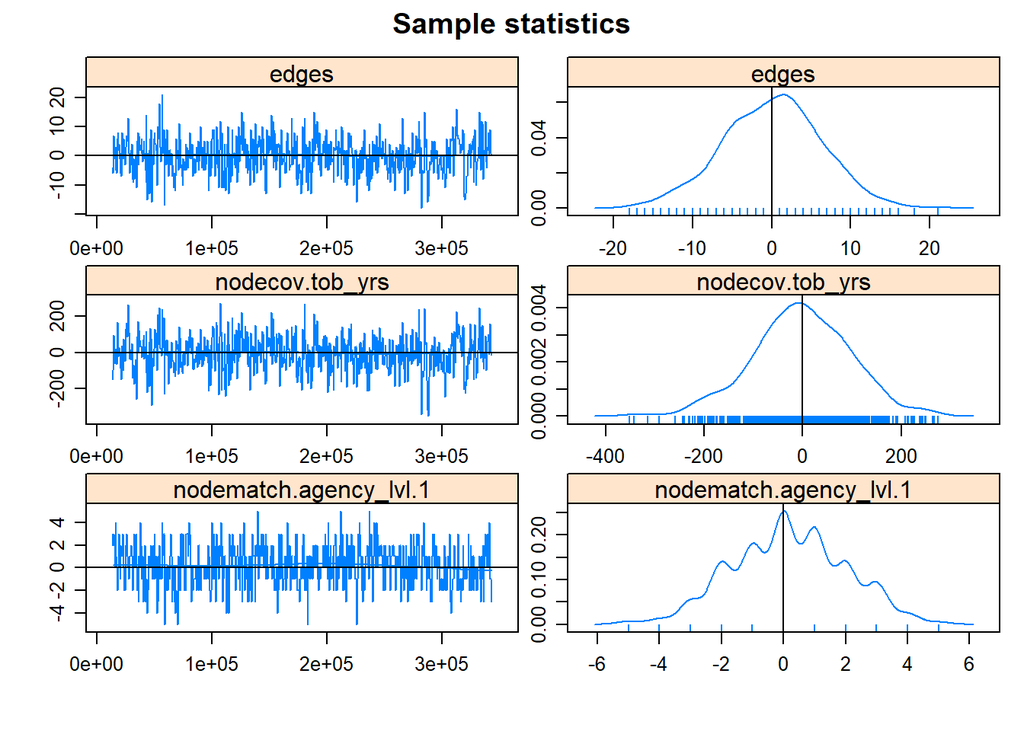

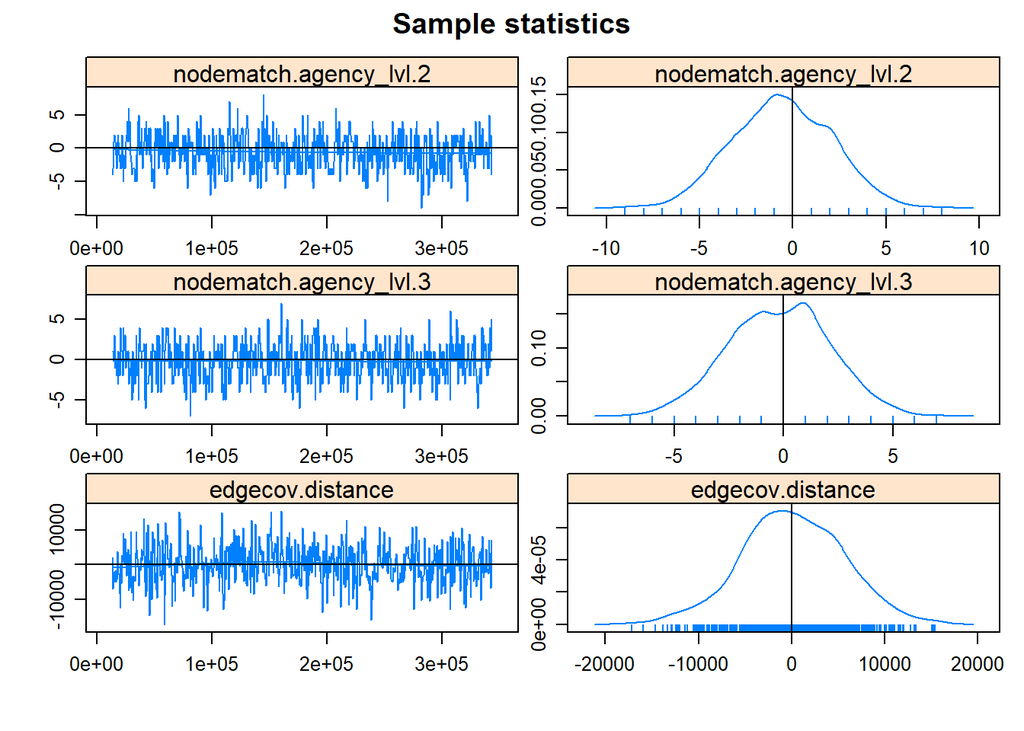

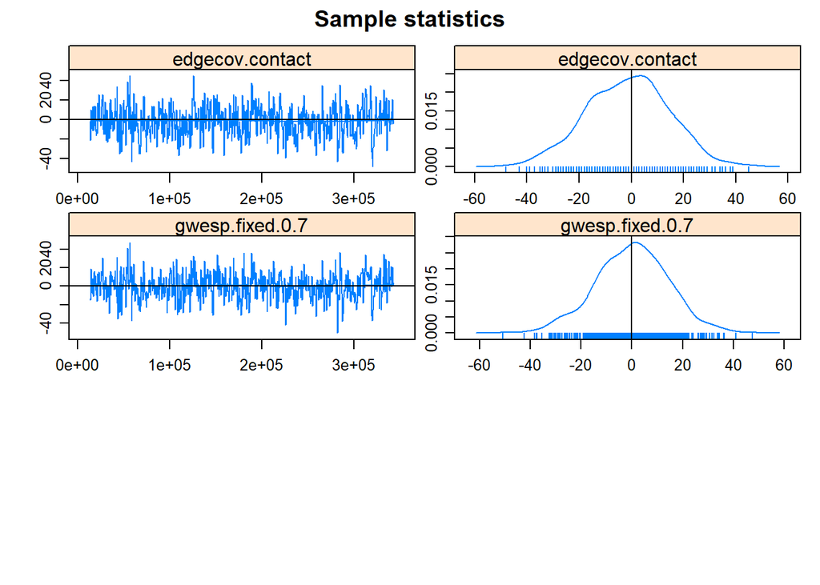

[output not shown]

### Examine simulated networks based on fitted models

Finally, once you have a model that you think is valid and interesting, you can produce simulated networks based on the model for further exploration.

```r
sim4 <- simulate(DSmod4, nsim=1, seed=569)
summary(sim4,print.adj=FALSE)
```

```
## Network attributes:
##   vertices = 25
##   directed = FALSE
##   hyper = FALSE
##   loops = FALSE
##   multiple = FALSE
##   bipartite = FALSE
##   title = IN_Diffusion
##  total edges = 107
##    missing edges = 0
##    non-missing edges = 107
##  density = 0.3566667
##
## Vertex attributes:
##
##  agency_cat:
##    numeric valued attribute
##    attribute summary:
##    Min. 1st Qu.  Median    Mean 3rd Qu.    Max.
##    1.00    2.00    2.00    3.24    5.00    6.00
##
##  agency_lvl:
##    numeric valued attribute
##    attribute summary:
##    Min. 1st Qu.  Median    Mean 3rd Qu.    Max.
##    1.00    1.00    2.00    2.04    3.00    3.00
##
##  lead_agency:
##    numeric valued attribute
##    attribute summary:
##    Min. 1st Qu.  Median    Mean 3rd Qu.    Max.
##    0.00    0.00    0.00    0.04    0.00    1.00
##
##  tob_yrs:
##    numeric valued attribute
##    attribute summary:
##    Min. 1st Qu.  Median    Mean 3rd Qu.    Max.
##    1.00    3.00    4.50    6.76    9.00   21.00
##   vertex.names:
##    character valued attribute
##    25 valid vertex names
##
## No edge attributes
```

The following code plots both the observed network and a simulated network based on DSmod4, to see how they compare. (Note that I found a mistake in the code in the book, and corrected it here.)

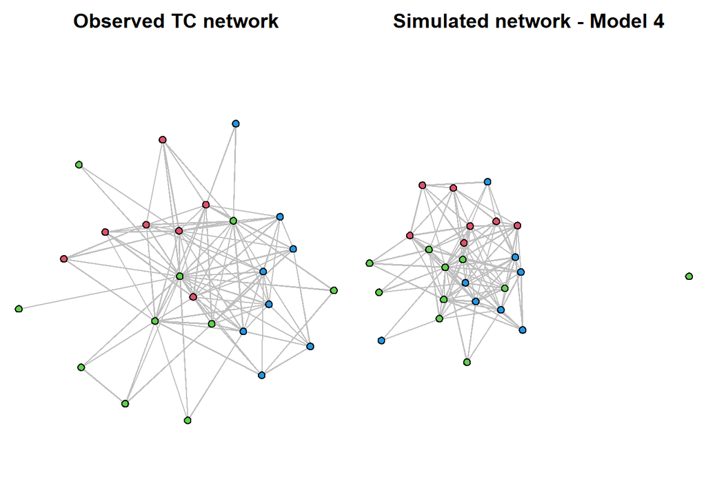

```r
op <- par(mfrow=c(1,2),mar=c(0,0,2,0))
lvlobs <- TCdiss %v% 'agency_lvl'
plot(TCdiss,usearrows=FALSE,
      vertex.col=lvlobs+1,
      edge.lwd=0.5,edge.col="grey75",
     main="Observed TC network")
lvl4 <- sim4 %v% 'agency_lvl'
plot(sim4,usearrows=FALSE,
      vertex.col=lvl4+1,
      edge.lwd=0.5,edge.col="grey75",
     main="Simulated network - Model 4")
```

```r
par(op)
```

E: To better understand how well DSmod4 is doing, you might want to simulate some networks from some of the other models. In particular, compare a simulated network from the null model (DSmod0) to both the observed network and our final model (DSmod4).